# Transcriptomic Analysis of MYC Target Genes as a Proxy for MYC Transcriptional Activity

Supplementary R Markdown — worked RNA-seq example (MDA-MB-231, GSE309250)

M. Arnal Segura (Peptomyc S.L., Barcelona, Spain)

2026-05-12

# 1 Description

This R Markdown document is supplementary material for the book chapter:

> Arnal Segura M. *Transcriptomic Analysis of MYC Target Genes as a Proxy for MYC Transcriptional Activity*. In: **The MYC Gene: Methods and Protocols** (3rd ed.).

It reproduces the bulk RNA-seq branch of the workflow described in the chapter and applies it to the public GEO series **GSE309250** (MDA-MB-231 breast cancer cells treated with 30 µM Omomyc — referred to as `DP30` in the sample names — or vehicle for 120 h, two biological replicates per condition). The pipeline implements:

1. Pre-processing and TMM normalization of the count matrix with `edgeR`.
2. Differential expression (DE) analysis with `limma` + `voom`.
3. MYC transcriptional activity inference using three complementary approaches:
   - Gene Set Enrichment Analysis (GSEA) on the DE-derived ranked list (`clusterProfiler`).
   - Gene Set Variation Analysis (GSVA) on the TMM log<sub>2</sub>-CPM normalized matrix (`GSVA`).
   - Univariate Linear Model (ULM) transcription-factor activity inference with the CollecTRI regulon (`decoupleR`).

The R session that produced and tested this document is recorded in the *Session information* section at the end of the document.

# 2 Software requirements

The pipeline was developed and tested under R 4.4.2. The Bioconductor / CRAN packages required to run the document are:

```r
library(data.table)            # Fast import of the table of counts
library(dplyr)                 # Pipe operator (%>%) and tidy data manipulation
library(edgeR)                 # TMM normalization of RNA-seq counts
library(limma)                 # DE analysis with voom + lmFit + eBayes
library(msigdbr)               # Access to MSigDB gene set collections
library(clusterProfiler)       # Gene Set Enrichment Analysis (GSEA)
library(enrichplot)            # dotplot() for gseaResult objects
library(GSEABase)              # GeneSet / GeneSetCollection containers
library(GSVA)                  # Gene Set Variation Analysis (GSVA)
library(SummarizedExperiment)  # Extract assay() from the GSVA result
library(ComplexHeatmap)        # Heatmap visualization
library(grid)                  # gpar() for heatmap graphical parameters
library(fastcluster)           # Fast hierarchical clustering
library(decoupleR)             # CollecTRI regulon retrieval + run_ulm()
```

Note that this script was prepared with `msigdbr` v7.5.1. The `msigdbr` API was modified in v9.0.0 (the `category` argument was renamed to `collection`); when using a newer version of `msigdbr` the calls in the *MSigDB MYC-related gene sets* section should be adapted accordingly.

# 3 Import of the table of counts (GEO accession GSE309250)

The table of counts is downloaded from the GEO supplementary FTP. Replace the URL by a local path if the file has been downloaded in advance.

```r
counts_url <- paste0(
  "https://ftp.ncbi.nlm.nih.gov/geo/series/GSE309nnn/GSE309250/",
  "suppl/GSE309250%5Fcounts%2Etxt%2Egz"
)

dt  <- fread(counts_url)
mat <- as.matrix(dt, rownames = 1)

# Four samples, two replicates per condition:
#   * MDAMB231_120h_DP30_B3, MDAMB231_120h_DP30_B4 -> Omomyc (30 uM)
#   * MDAMB231_120h_veh_B3,  MDAMB231_120h_veh_B4  -> vehicle
colnames(mat)
```

```
## [1] "MDAMB231_120h_DP30_B3" "MDAMB231_120h_DP30_B4" "MDAMB231_120h_veh_B3"
## [4] "MDAMB231_120h_veh_B4"
```

# 4 Pre-processing

Low-count genes are removed before normalization to stabilize the mean–variance estimation and to reduce the multiple-testing burden in the downstream DE analysis.

```r
dim(mat)  # 26364 genes x 4 samples
```

```
## [1] 26364     4
```

```r
# Retain genes with more than 10 counts in all 4 samples
keep      <- rowSums(mat > 10) >= 4
counts_f  <- mat[keep, ]
dim(counts_f)  # 13367 genes x 4 samples
```

```
## [1] 13367     4
```

# 5 Normalization: TMM and log<sub>2</sub>-CPM

The Trimmed Mean of M-values (TMM) method implemented in `edgeR` is used to compute per-sample normalization factors. The resulting `DGEList` is reused to build the log<sub>2</sub>-CPM matrix that feeds GSVA.

```r
d <- DGEList(counts = counts_f)
d <- calcNormFactors(d, method = "TMM")

# log2-CPM expression matrix (prior count stabilizes the variance near zero)
cpm_matrix <- cpm(d, log = TRUE, prior.count = 1)
```

# 6 Differential expression analysis (limma + voom)

A no-intercept design is used so that pairwise contrasts can be specified directly between the two groups (Omomyc vs. vehicle).

```r
cond <- ifelse(grepl("veh", colnames(counts_f)), "vehicle", "omomyc")
table(cond)
```

```
## cond
##  omomyc vehicle
##       2       2
```

```r
design <- model.matrix(~ 0 + cond)
rownames(design) <- colnames(counts_f)
colnames(design) <- gsub("cond", "", colnames(design))

# Contrast of interest: Omomyc-treated samples versus vehicle-treated samples
cont_matrix <- makeContrasts(OMOvsVEH = omomyc - vehicle, levels = design)
```

voom() is called on the matrix of raw counts. Quantile normalization is requested as an optional between-array correction; whether this option is appropriate should be evaluated empirically (the un-normalized voom output should also be inspected).

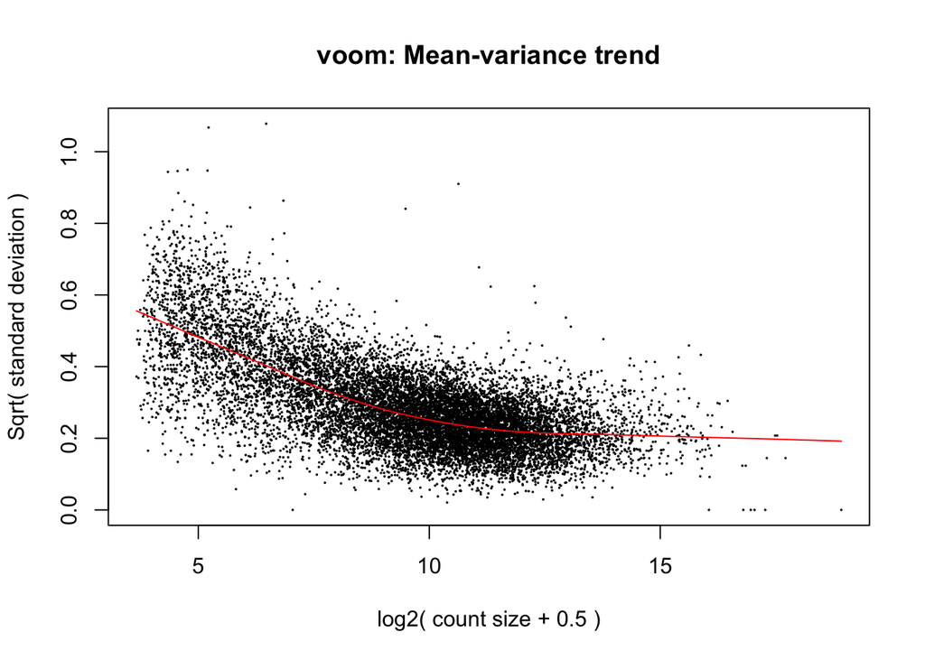

```r
voom_res <- voom(counts_f, design, plot = TRUE, normalize = "quantile")
```

```r
fit      <- lmFit(voom_res, design)
fit_main <- contrasts.fit(fit, cont_matrix)
fit_main <- eBayes(fit_main)

top_diff <- topTable(fit_main, coef = "OMOvsVEH", number = Inf, adjust.method = "fdr")
head(top_diff)
```

|  | logFC | AveExpr | t | P.Value | adj.P.Val | B |
| --- | --- | --- | --- | --- | --- | --- |
| VSTM2L | 2.206950 | 7.566690 | 44.74771 | 6.889237e-16 | 3.739622e-12 | 26.86781 |
| ITGA10 | 2.608069 | 7.014784 | 44.24351 | 8.001724e-16 | 3.739622e-12 | 26.68332 |
| ASNS | -2.325560 | 6.852898 | -43.13405 | 1.119061e-15 | 3.739622e-12 | 26.34457 |
| BMF | 2.588461 | 5.935813 | 43.40228 | 1.031097e-15 | 3.739622e-12 | 26.31092 |
| DKK1 | -2.700451 | 6.588101 | -41.42367 | 1.909104e-15 | 5.103798e-12 | 25.80137 |
| CST3 | 1.858028 | 9.426343 | 40.44377 | 2.618326e-15 | 5.228282e-12 | 25.62090 |

# 7 MYC-related gene sets from MSigDB

The Hallmark (`H`) and curated (`C2`) collections are downloaded with `msigdbr` and filtered to keep gene sets whose names contain `MYC_`, `MYCN_`, or `MYCL_`. This selection corresponds to the 51 MYC-related gene sets used in the chapter (Fig. 2).

```r
H <- msigdbr(species = "Homo sapiens", category = "H")
H_symbol <- as.data.frame(H %>% dplyr::select(gs_name, gene_symbol))
H_symbol$collection <- "Hallmark"
dim(H_symbol)   # 8209 rows x 3 columns
```

```
## [1] 8209    3
```

```r
C2 <- msigdbr(species = "Homo sapiens", category = "C2")
C2_symbol <- as.data.frame(C2 %>% dplyr::select(gs_name, gene_symbol))
C2_symbol$collection <- "C2"
dim(C2_symbol)  # ~5.9e5 rows x 3 columns (size depends on the MSigDB version)
```

```
## [1] 594903      3
```

```r
# Merge both collections and retain MYC/MYCN/MYCL gene sets
all_gs  <- rbind(H_symbol, C2_symbol)
myc_gsc <- all_gs[grepl("MYC_|MYCN_|MYCL_", all_gs$gs_name), ]
length(unique(myc_gsc$gs_name))  # 51 MYC-related gene sets
```

```
## [1] 51
```

# 8 Gene Set Enrichment Analysis (GSEA)

GSEA is applied to a pre-ranked gene list. As described in the chapter (Methods §3.3.3), the ranking metric combines the magnitude and the direction of the change observed in the DE analysis as $-\log_{10}(p) \times \text{sign}(\log_2 \mathrm{FC})$.

```r
signL  <- sign(top_diff$logFC)
logP   <- -log10(top_diff$P.Value)
metric <- logP * signL
names(metric) <- rownames(top_diff)
metric <- sort(metric, decreasing = TRUE)

# GSEA relies on a random permutation step; the seed is fixed for reproducibility.
set.seed(2)
gsea_res <- GSEA(
  geneList     = metric,
  TERM2GENE    = myc_gsc[, c("gs_name", "gene_symbol")],
  verbose      = FALSE,
  eps          = 0,
  pvalueCutoff = 0.05
)
gsea_tbl <- gsea_res@result

# HALLMARK_MYC_TARGETS_V1 and DANG_MYC_TARGETS_UP are negatively enriched, consistent
# with MYC inhibition in the Omomyc-vs-vehicle contrast.
gsea_tbl[, c("NES", "pvalue", "p.adjust")]
```

|  | NES | pvalue | p.adjust |
| --- | --- | --- | --- |
| HALLMARK_MYC_TARGETS_V1 | -3.095556 | 2.178940e-39 | 1.002312e-37 |
| DANG_MYC_TARGETS_UP | -2.592512 | 1.114334e-16 | 2.562969e-15 |
| SATOH_COLORECTAL_CANCER_MYC_UP | -2.576784 | 3.827376e-13 | 4.401483e-12 |
| SCHLOSSER_MYC_TARGETS_REPRESSED_BY_SERUM | -2.345180 | 3.788911e-13 | 4.401483e-12 |
| HALLMARK_MYC_TARGETS_V2 | -2.582449 | 3.231301e-12 | 2.972797e-11 |
| KIM_MYC_AMPLIFICATION_TARGETS_UP | -2.197595 | 1.766030e-11 | 1.353956e-10 |
| SCHUHMACHER_MYC_TARGETS_UP | -2.395335 | 4.036781e-10 | 2.652742e-09 |
| SCHLOSSER_MYC_TARGETS_AND_SERUM_RESPONSE_DN | -2.459061 | 1.081199e-09 | 6.216895e-09 |
| SCHLOSSER_MYC_TARGETS_AND_SERUM_RESPONSE_UP | -2.360218 | 1.485298e-08 | 7.591521e-08 |
| YU_MYC_TARGETS_UP | -2.373135 | 3.966258e-08 | 1.824479e-07 |

[output cut: 17 more lines]

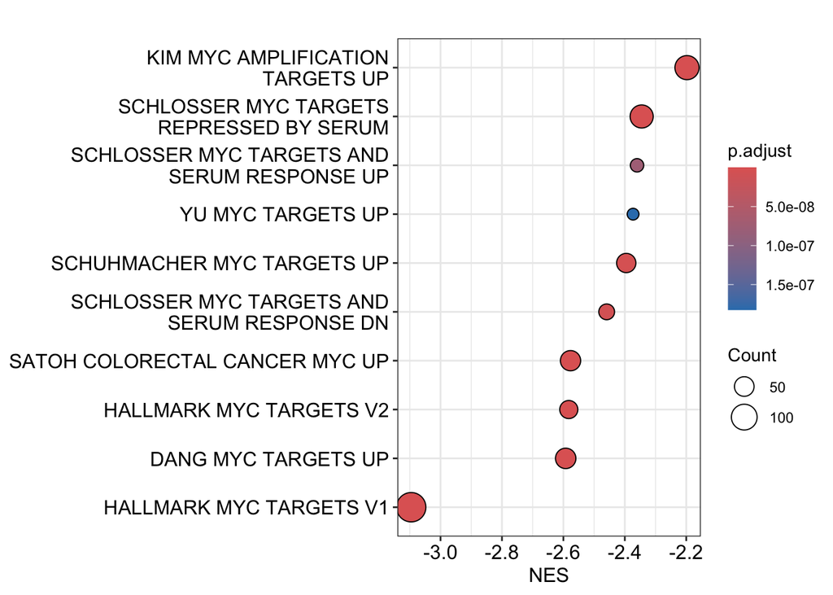

GSEA results for the MYC-related MSigDB gene sets, dots coloured by adjusted p-value and ordered by normalized enrichment score (NES).

```r
dotplot(gsea_res, x = "NES")
```

# 9 Gene Set Variation Analysis (GSVA)

GSVA produces a sample-wise enrichment score for every gene set, independently of the contrast definition. The MYC-related gene sets are reorganized as a `GeneSetCollection` before running `gsva()`.

```r
gene_lists <- split(myc_gsc$gene_symbol, myc_gsc$gs_name)

gsc <- GeneSetCollection(
  lapply(names(gene_lists), function(name) {
    GeneSet(
      unique(as.character(gene_lists[[name]])),
      setName    = name,
      geneIdType = SymbolIdentifier()  # change if Entrez or Ensembl identifiers are used
    )
  })
)
```

```r
par_obj  <- gsvaParam(cpm_matrix, gsc, minSize = 5, maxSize = 500)
gsva_res <- gsva(par_obj)

# Extract the score matrix
gsva_m=gsva_res[1:nrow(gsva_res),1:ncol(gsva_res)]
dim(gsva_m)#47  4
```

```
## [1] 47  4
```

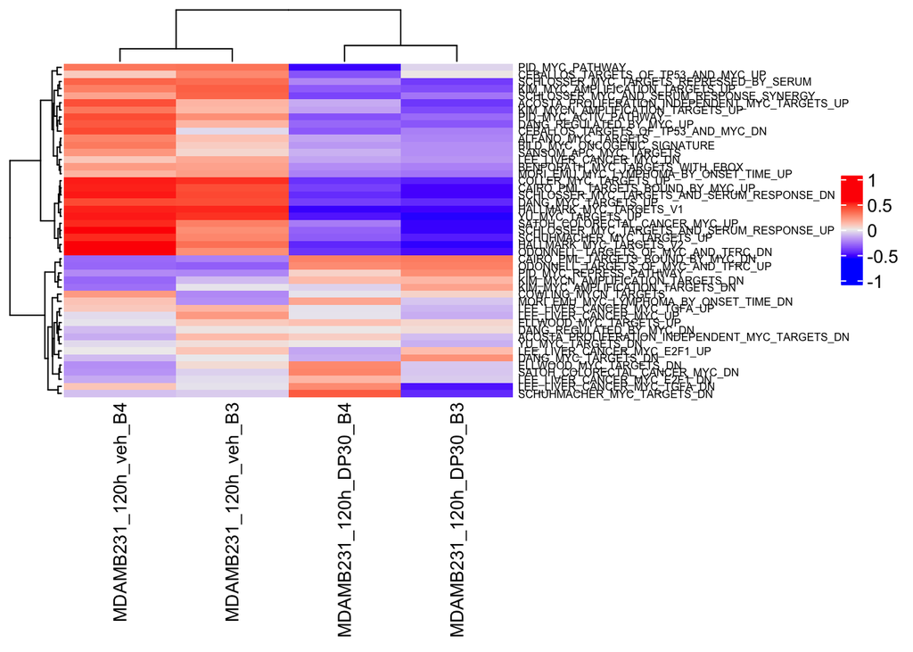

Heatmap of GSVA enrichment scores for MYC-related gene sets. Ward.D2 hierarchical clustering on Euclidean distance is used for both rows and columns.

```r
fh <- function(x) fastcluster::hclust(dist(x), method = "ward.D2")

Heatmap(
  gsva_m,
  name            = " ",
  cluster_rows    = fh,
  cluster_columns = fh,
  row_names_gp    = gpar(fontsize = 6),
  column_names_gp = gpar(fontsize = 10)
)
```

```r
# GSVA scores of MYC-related gene sets cleanly separate Omomyc-treated and
# vehicle-treated samples; HALLMARK_MYC_TARGETS_V1 is among the most discriminant.
```

# 10 Transcription-factor activity with CollecTRI and ULM

The CollecTRI regulon is retrieved with `decoupleR::get_collectri()`. The chapter applies the Univariate Linear Model (ULM) at the contrast level, using the same $-\log_{10}(p) \times \text{sign}(\log_2 \mathrm{FC})$ gene-level metric that feeds GSEA. The metric is reshaped into a one-column matrix so that the contrast name is preserved in the `condition` column of the `run_ulm()` output.

```r
net <- get_collectri(organism = "human", split_complexes = FALSE)

# One-column matrix: rows = genes, column = contrast name
metric_mat <- matrix(
  metric,
  ncol     = 1,
  dimnames = list(names(metric), "OMOvsVEH")
)

contrast_acts <- run_ulm(
  mat     = metric_mat,
  net     = net,
  .source = "source",
  .target = "target",
  .mor    = "mor",
  minsize = 5
)
contrast_acts <- as.data.frame(contrast_acts)

# MYC activity in the Omomyc-vs-vehicle contrast: negative ULM score with a
# significant p-value, consistent with MYC inhibition.
contrast_acts[contrast_acts$source == "MYC", ]
```

|  | statistic | source | condition | score | p_value |
| --- | --- | --- | --- | --- | --- |
| 312 | ulm | MYC | OMOvsVEH | -6.706599 | 2.072225e-11 |

[session information not shown]